# clusterização - ações da minha carteira

Samantha Escaleira Egypto Rosa

# Finalidade

A ideia é agrupar as ações da minha carteira de investimentos com base em uma análise quantitativa que olha sobretudo a peformance dessas ações na Bolsa de Valores, [sem levar em conta as tradicionais métricas fundamentalistas e tão pouco uma análise técnica de ações](https://valorinveste.globo.com/blogs/alexandre-espirito-santo/coluna/bolsa-nao-e-picole.ghtml), pois aqui não iremos fazer análises gráficas.

O único resquício de análise fundamentalista é dado pela presença do indicador dividend yield (retorno dos dividendos pagos em relação ao preço da ação). Vejamos se ele será determinante, em comparação com os demais indicadores unicamente de performance em Bolsa, para a separação das empresas.

A partir deste agrupamento, verei se difere muito dos agrupamentos que naturalmente seriam feitos em uma análise tradicional fundamentalista (ex.: provavelmente um analista fundamentalista de ações não diria que Banco do Brasil e Magazine Luiza são empresas semelhantes olhando para o setor de atuação, maturidade do negócio - [empresas de valor x crescimento](https://valorinveste.globo.com/blogs/andre-rocha/post/2019/11/qual-tipo-de-acao-e-melhor-a-de-valor-ou-a-de-crescimento-se-lembra-da-brasil-pharma.ghtml) - , etc.)

Para isso, coletei alguns indicadores-chave de performance¹ no período de 30/12/2020 a 20/05/2021². Abaixo, a breve descrição de cada indicador:

1. **Máximo Draw Up**: maior retorno acumulado do ativo no período selecionado (30/12/20 a 20/05/21.)
2. **Observações no Máximo Draw Up**: número de dias consecutivos em que foi observado o maior retorno acumulado da ação no período selecionado (30/12/20 a 20/05/21).
3. **Máximo Draw Down**: maior queda acumulada de um ativo desde o ponto máximo ao mínimo no período analisado (30/12/20 a 20/05/21).
4. **Observações no Máximo Draw Down**: número de dias consecutivos em que foi observada a maior queda acumulada da ação durante o período (30/12/20 a 20/05/21).
5. **Número de Vezes Acima do Benchmark - IQT Ações Ativo**: número de dias em que a ação teve um retorno maior que o benchmark escolhido, o índice IQT Ações Ativo³, durante período escolhido (30/12/20 a 20/05/21).
6. **% de Vezes Abaixo do Benchmark - IQT Ações Ativo**: número de dias, em %, em que a ação teve um retorno menor que o benchmark escolhido, o índice IQT Ações Ativo³, durante período escolhido (30/12/20 a 20/05/21.
7. **Dividend Yield (Cotação Final)**: razão entre o somatório dos dividendos (cuja data ex<sup>4</sup> incide dentro do período selecionado) e o preço de fechamento da ação na data final do período selecionado (30/12/20 a 20/05/21).
8. **Alfa - IGP-M/IQT Ações Ativo**: Diferença entre o excesso de retorno médio entre um ativo (no caso, as ações das empresas selecionadas) e um ativo sem risco (no caso, escolhi o IGP-M<sup>5</sup>), e o excesso de retorno médio entre um benchmark (IQT Ações Ativo) e o mesmo ativo sem risco, ajustado pelo beta do ativo, no período analisado (30/12/20 a 20/05/21). Também conhecido como Alfa de Jensen, consiste em uma regressão entre o excesso da rentabilidade de um ativo contra o mercado. Assim, pode-se dizer que ele representa o retorno médio do ativo sobre o ativo sem risco, dado o beta e o retorno médio esperado do mercado. O alfa expressa o sucesso (se o alfa for positivo) ou o fracasso (alfa negativo) do retorno do ativo em relação ao mercado.
9. **Beta - IGP-M/IQT Ações Ativo**: Covariância do excesso de retorno entre um ativo e um ativo sem risco, e o excesso de retorno entre um benchmark sobre o mesmo ativo sem risco, dividido pela variância do excesso de retorno entre o benchmark e o ativo sem risco, no período selecionado (30/12/20 a 20/05/21). Traduzindo, representa a relação entre a volatilidade do retorno de um ativo (risco do ativo) e a volatilidade do mercado (risco de mercado). Portanto, é uma medida do risco que um investidor está exposto ao investir em um ativo em particular em comparação ao risco do mercado como um todo. Se um ativo se comporta exatamente como o benchmark, dizemos que ele tem beta=1. Se variar mais que o benchmark, ele terá beta > 1. Se variar menos, então beta < 1. Um ativo com beta muito maior do que 1, por exemplo, tende a subir mais que o benchmark quando este está em alta. Em compensação, tende a cair mais quando há baixa. Ativos com beta < 1 são usualmente chamados de “defensivos”, pois, com eles em sua carteira, você atenua os efeitos da oscilação do mercado sobre ela.
10. **Retorno do Maior Período de Ganhos**: maior retorno acumulado do ativo considerando a maior sequência de dias com retornos positivos consecutivos do ativo durante o período selecionado (30/12/20 a 20/05/21).
11. **Retorno do Maior Período de Perdas**: menor retorno acumulado do ativo considerando a maior sequência de dias com retornos negativos consecutivos do ativo durante o período selecionado (30/12/20 a 20/05/21).
12. **Volatilidade**: dispersão dos retornos do ativo em relação a seu retorno médio no período selecionado (30/12/20 a 20/05/21).

## 1. Visualização

Visualizando rapidamente, parece que não temos problemas nos dados:

|  | Empresa | Máximo Draw Up | Máximo Drawdown | Observações no Máximo Draw Up | Observações no Máximo Drawdown | Número de Vezes Acima do Benchmark - IQT Ações Ativo | % de Vezes Abaixo do Benchmark - IQT Ações Ativo | Volatilidade | Alfa - IGP-M/IQT Ações Ativo | Beta - IGP-M/IQT Ações Ativo | Dividend Yield (Cotação Final) | Retorno do Maior Período de Ganhos | Retorno do Maior Período de Perdas |
| --- | --- | --- | --- | --- | --- | --- | --- | --- | --- | --- | --- | --- | --- |
| 1 | AMBEV S/A ON - ABEV3 | 0.1523224044 | -0.176450759 | 5 | 32 | 50 | 0.4845360825 | 0.3133921007 | 0.116866418923112 | 0.697640066039128 | 0.004367299146 | 0.1523224044 | -0.06262763785 |
| 2 | B3 ON NM - B3SA3 | 0.0746777862 | -0.1848888913 | 3 | 58 | 43 | 0.5567010309 | 0.3085355289 | -0.475736784963127 | 1.16022450227082 | 0.03186629255 | 0.05284280936 | -0.0546641791 |
| 3 | BBSEGURIDADE ON NM - BBSE3 | 0.05287275291 | -0.2564419549 | 2 | 85 | 35 | 0.6391752577 | 0.2250026823 | -0.736366589469406 | 0.786959965325726 | 0.02039592961 | 0.04380791912 | -0.0868430861 |
| 4 | BRASIL ON NM - BBAS3 | 0.09834888729 | -0.2890817438 | 4 | 34 | 42 | 0.5670103093 | 0.3574225369 | -0.478319140772875 | 1.02563819337993 | 0.01777704173 | 0.09834888729 | -0.1470886076 |
| 5 | COGNA ON ON NM - COGN3 | 0.1274238227 | -0.2510373444 | 4 | 34 | 40 | 0.587628866 | 0.4392780579 | -0.428569484545027 | 1.46633651933995 | 0 | 0.1274238227 | -0.1525821596 |
| 6 | CVC BRASIL ON NM - CVCB3 | 0.2716879623 | -0.2774538387 | 4 | 45 | 44 | 0.5463917526 | 0.5619859878 | 0.551848299707717 | 1.56199100767336 | 0 | 0.1583564174 | -0.06265539533 |
| 7 | EZTEC ON NM - EZTC3 | 0.1046068583 | -0.3327940837 | 4 | 47 | 39 | 0.5979381443 | 0.4494072389 | -0.808052836078825 | 1.77178619491425 | 0.01372023081 | 0.1046068583 | -0.09647779479 |
| 8 | IRBBRASIL RE ON NM - IRBR3 | 0.178187404 | -0.2911084044 | 1 | 47 | 37 | 0.618556701 | 0.4810501849 | -0.804647890157671 | 1.13251067398492 | 0 | 0.02487562189 | -0.1015089163 |
| 9 | ITAUSA PN N1 - ITSA4 | 0.07796257796 | -0.2057698071 | 4 | 35 | 37 | 0.618556701 | 0.3019954046 | -0.346845272038773 | 0.912893581168364 | 0.008998696462 | 0.07796257796 | -0.08854125426 |
| 10 | JBS ON NM - JBSS3 | 0.1064680233 | -0.1375254325 | 6 | 16 | 62 | 0.3608247423 | 0.3013129128 | 0.522441771971138 | 0.545872378596208 | 0.03401404115 | 0.06120760959 | -0.02453740949 |

[output cut: 12 more lines]

## 2. Análise exploratória

Resumo estatístico dos dados:

```
##    Empresa          Máximo Draw Up    Máximo Drawdown
##  Length:22          Min.   :0.05287   Min.   :-0.3960
##  Class :character   1st Qu.:0.09570   1st Qu.:-0.2906
##  Mode  :character   Median :0.12473   Median :-0.2636
##                     Mean   :0.13006   Mean   :-0.2491
##                     3rd Qu.:0.16703   3rd Qu.:-0.1997
##                     Max.   :0.27169   Max.   :-0.1375
##  Observações no Máximo Draw Up Observações no Máximo Drawdown
##  Min.   :1.000                 Min.   :14.00
##  1st Qu.:2.000                 1st Qu.:32.50
##  Median :4.000                 Median :40.00
##  Mean   :3.818                 Mean   :41.32
##  3rd Qu.:5.000                 3rd Qu.:47.00
##  Max.   :8.000                 Max.   :85.00
##  Número de Vezes Acima do Benchmark - IQT Ações Ativo
##  Min.   :35.00
##  1st Qu.:39.25
##  Median :42.50
##  Mean   :44.41
##  3rd Qu.:49.50
##  Max.   :62.00
##  % de Vezes Abaixo do Benchmark - IQT Ações Ativo  Volatilidade
##  Min.   :0.3608                                   Min.   :0.2250
##  1st Qu.:0.4897                                   1st Qu.:0.3224
##  Median :0.5619                                   Median :0.3905
##  Mean   :0.5422                                   Mean   :0.3995
##  3rd Qu.:0.5954                                   3rd Qu.:0.4617
##  Max.   :0.6392                                   Max.   :0.5620
##  Alfa - IGP-M/IQT Ações Ativo Beta - IGP-M/IQT Ações Ativo
##  Min.   :-0.8854              Min.   :0.2307
##  1st Qu.:-0.7876              1st Qu.:0.8044
##  Median :-0.3402              Median :1.1271
##  Mean   :-0.2293              Mean   :1.1292
##  3rd Qu.: 0.1208              3rd Qu.:1.4864
##  Max.   : 0.6587              Max.   :1.7803
##  Dividend Yield (Cotação Final) Retorno do Maior Período de Ganhos
##  Min.   :0.000000               Min.   :0.02488
##  1st Qu.:0.000000               1st Qu.:0.05819
##  Median :0.005698               Median :0.09753
##  Mean   :0.011202               Mean   :0.10103
##  3rd Qu.:0.019741               3rd Qu.:0.14610
##  Max.   :0.037959               Max.   :0.19216
##  Retorno do Maior Período de Perdas
##  Min.   :-0.17500
##  1st Qu.:-0.12828
##  Median :-0.09080
##  Mean   :-0.09376
##  3rd Qu.:-0.06037
##  Max.   :-0.02454
```

Há empresas outliers na minha carteira? Olhemos as distribuições, primeiramente:

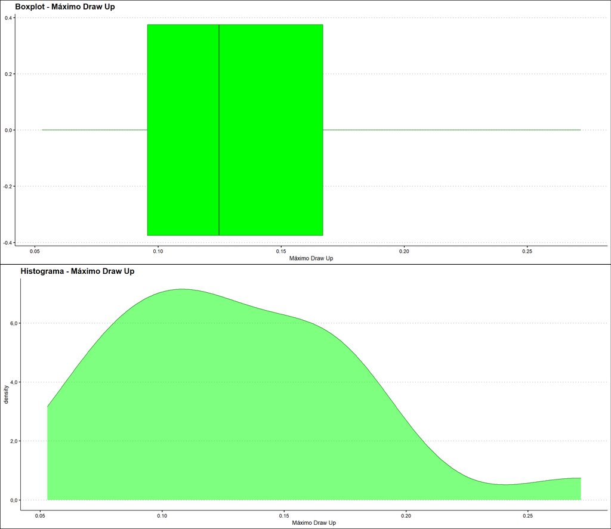

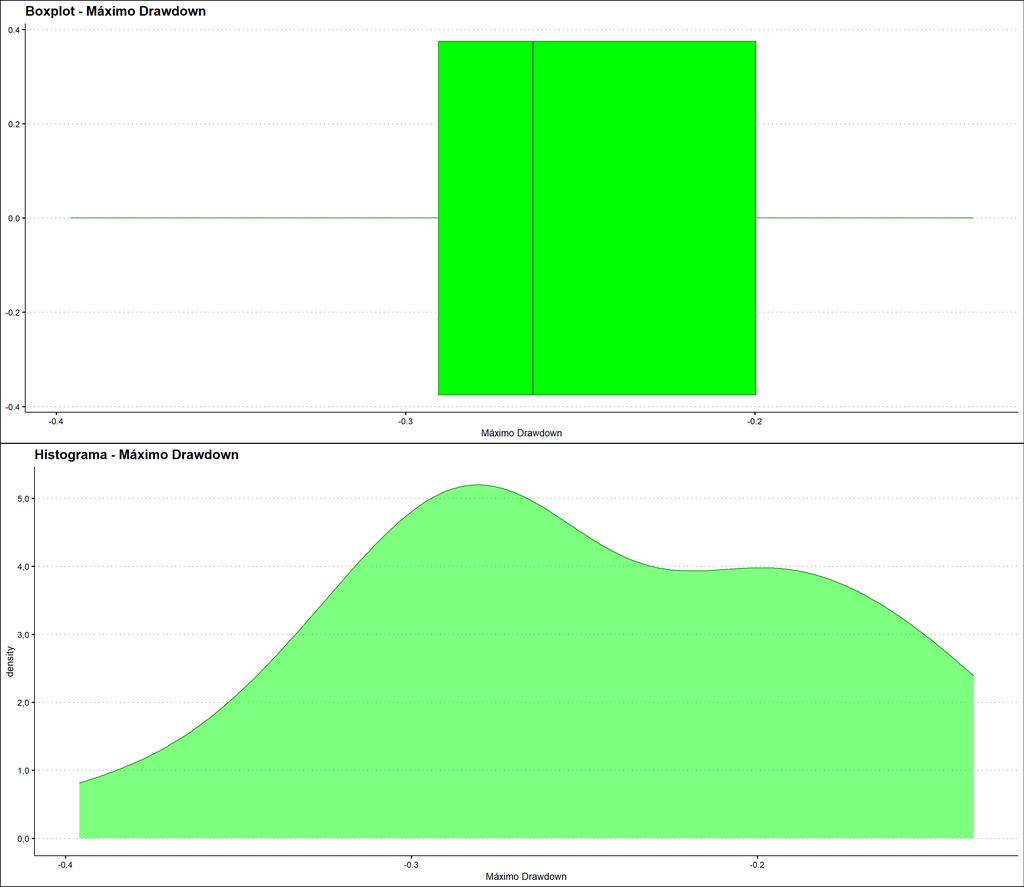

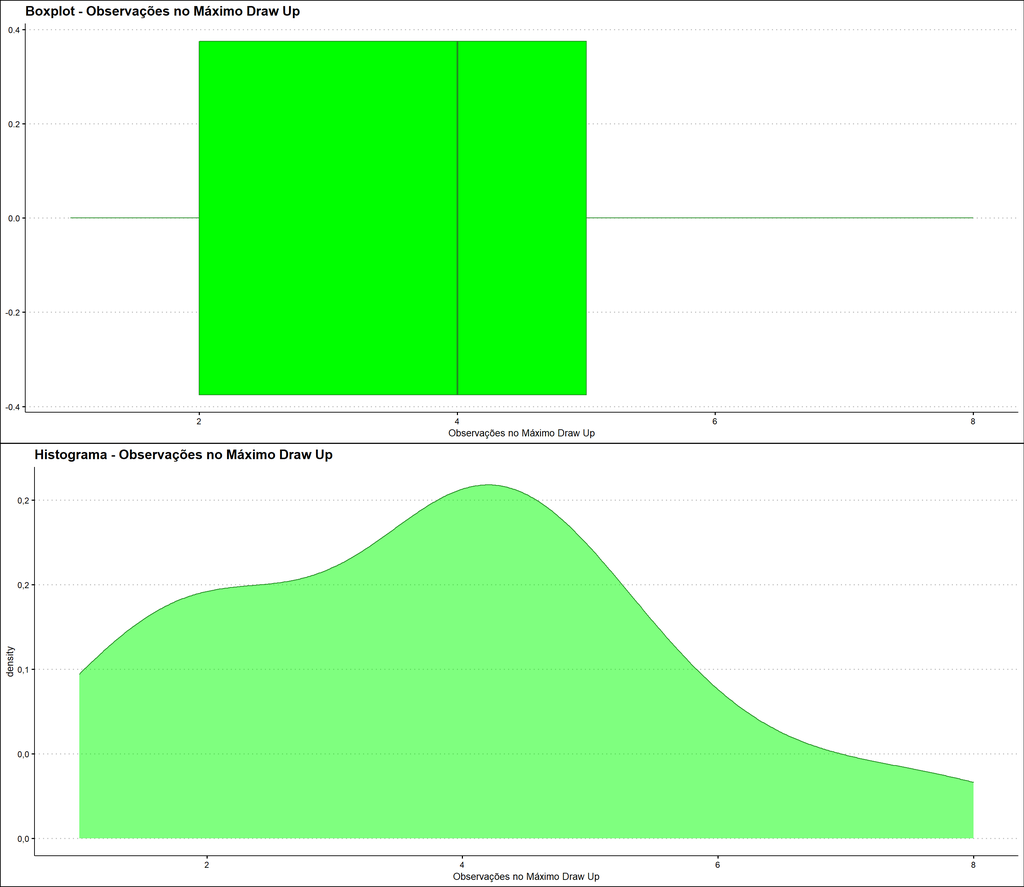

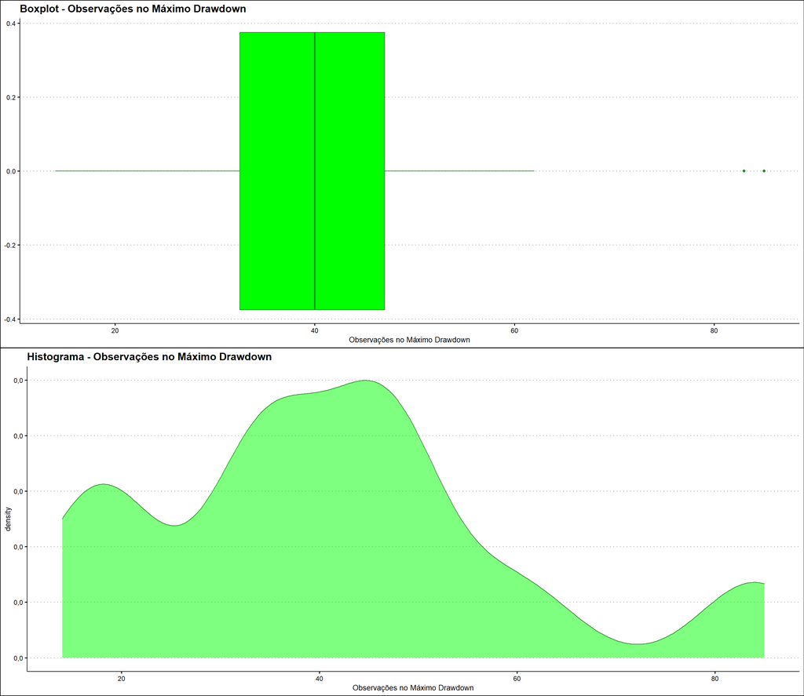

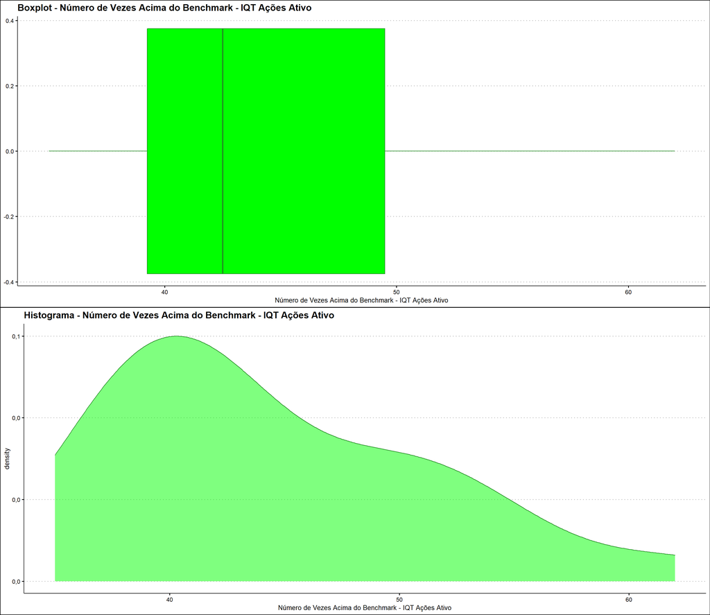

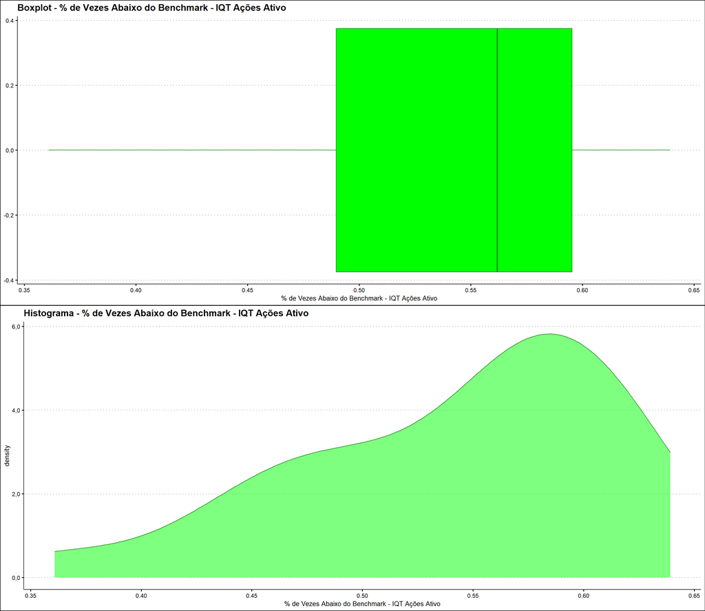

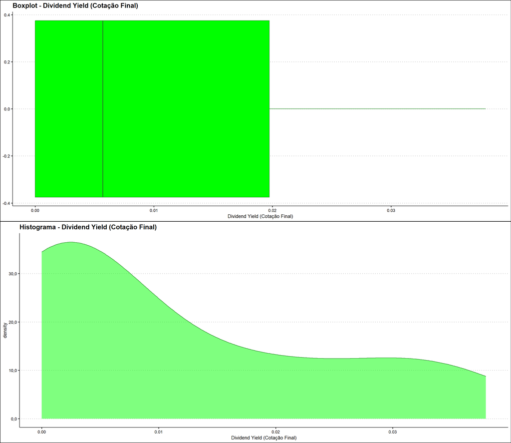

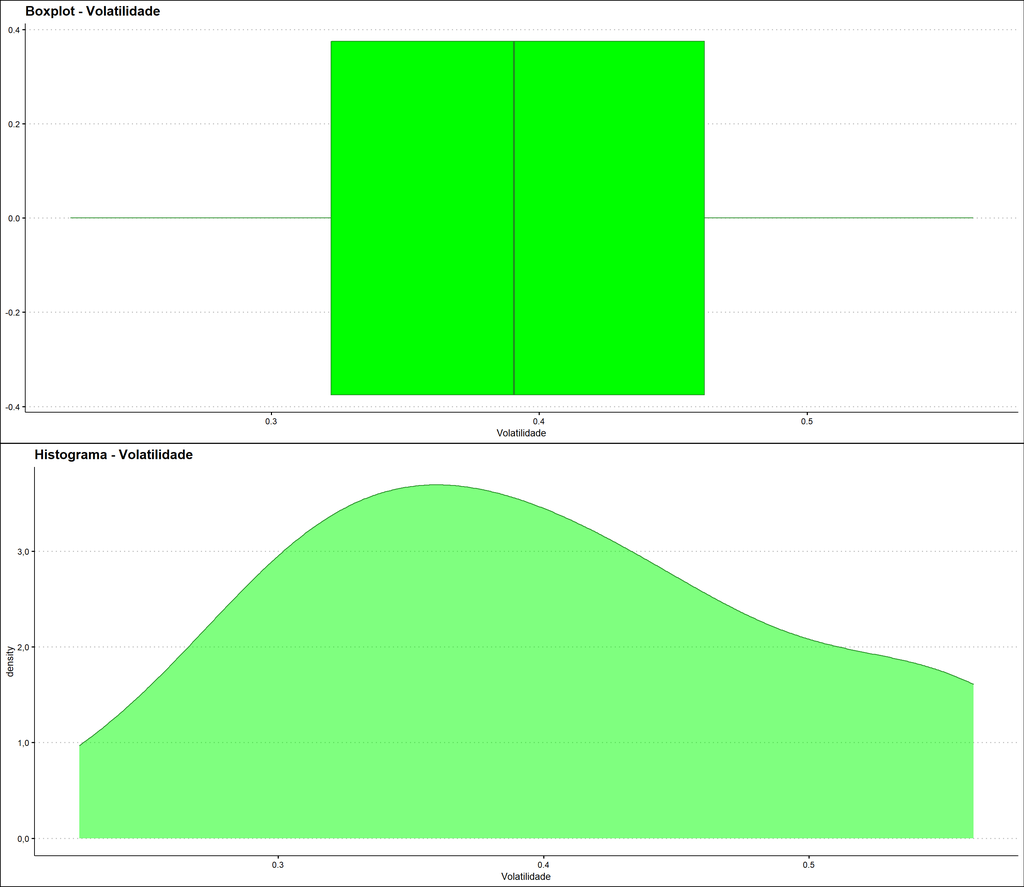

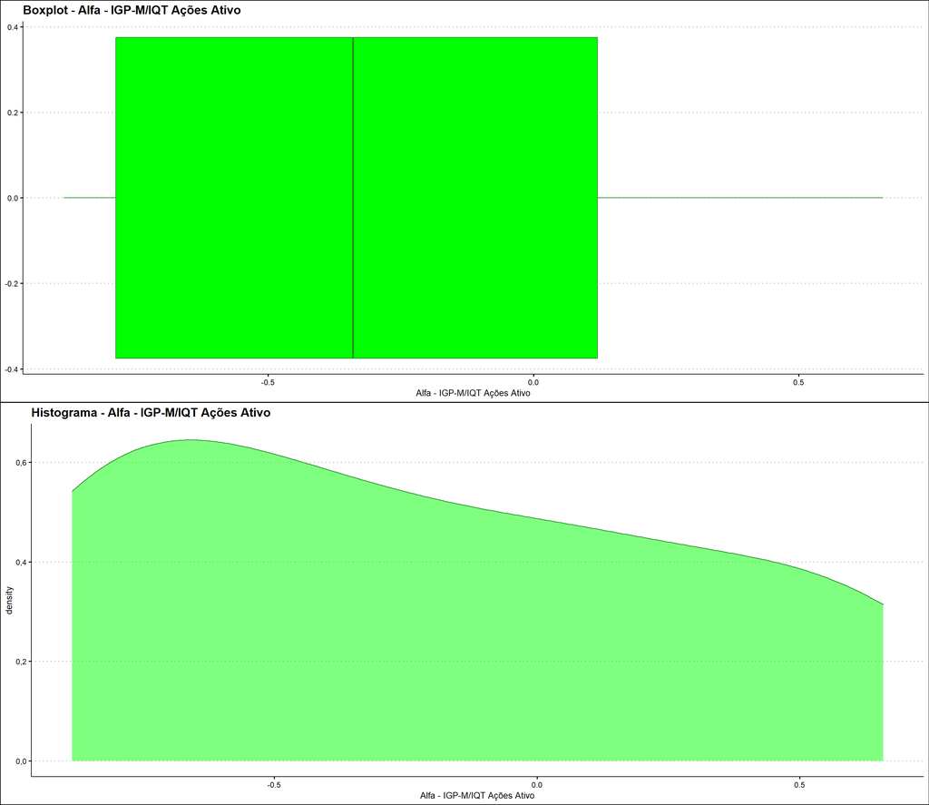

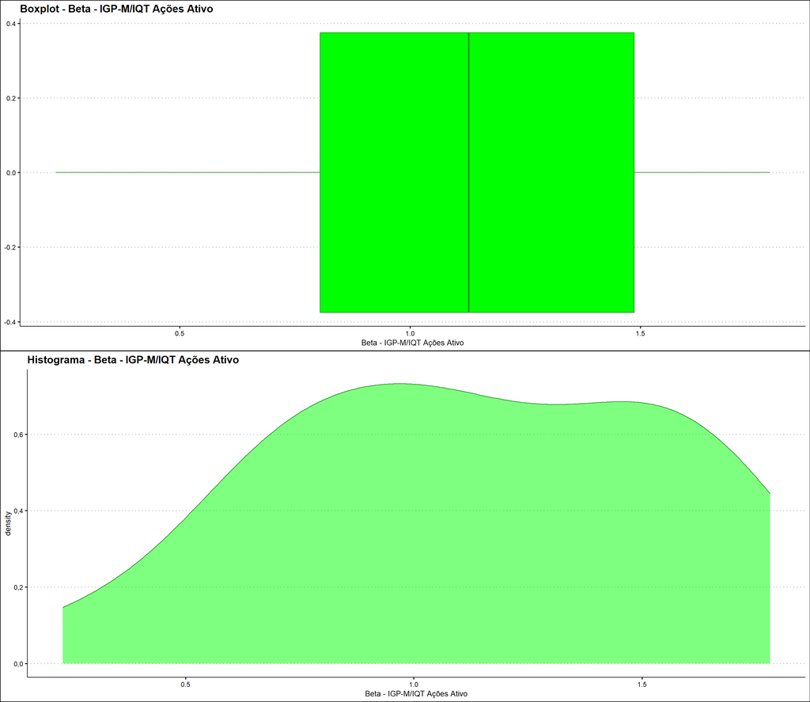

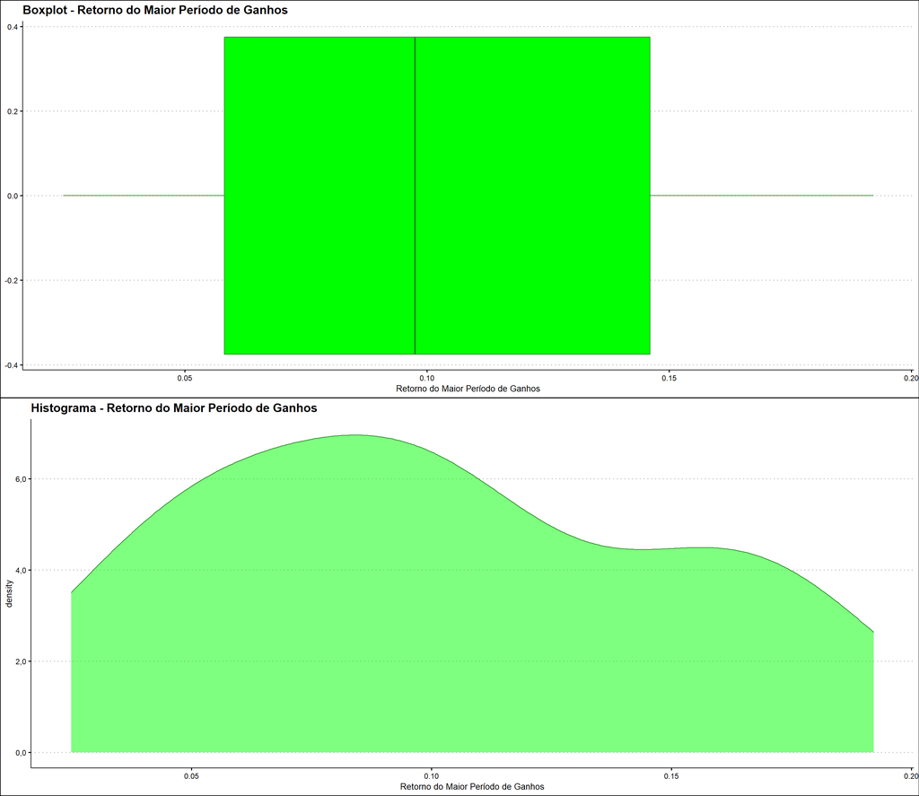

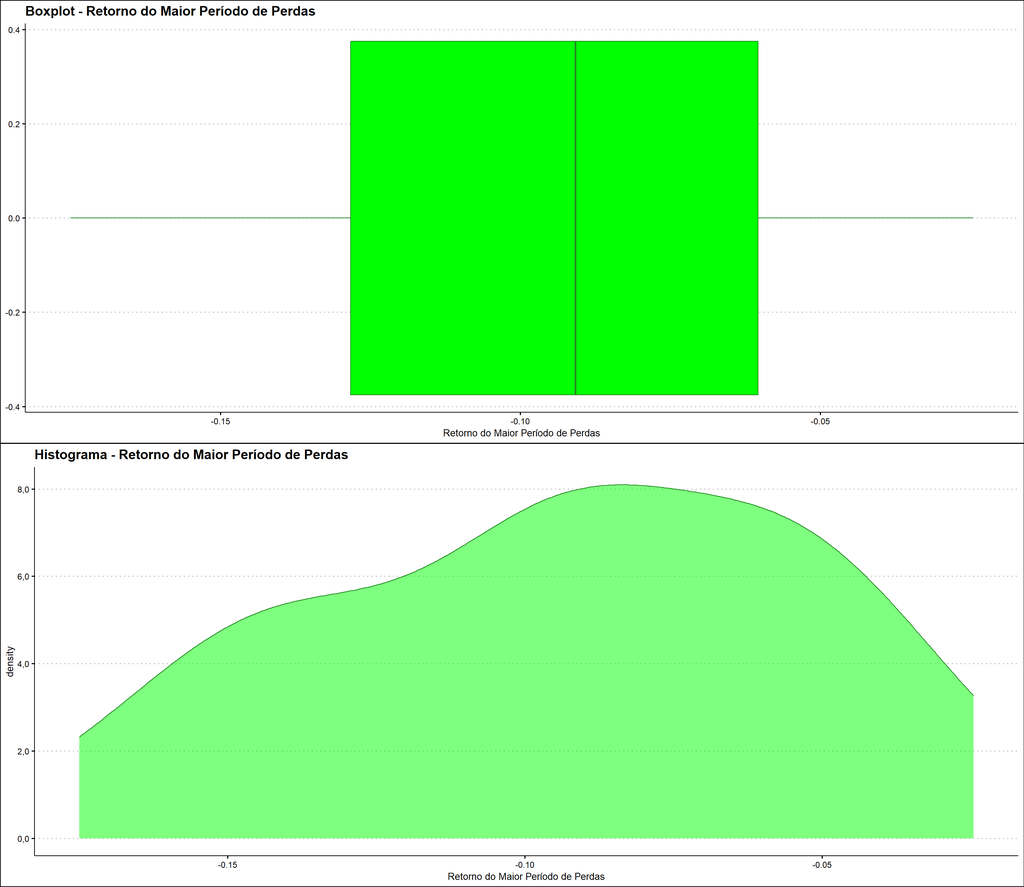

Vemos a maioria dos atributos com distribuições assimétricas, vamos investigar mais a presença de outliers com o método isolation forest:

```
## INFO  [23:13:22.862] Building Isolation Forest ...
## INFO  [23:13:22.959] done
## INFO  [23:13:22.970] Computing depth of terminal nodes ...
## INFO  [23:13:24.113] done
## INFO  [23:13:24.128] Completed growing isolation forest
```

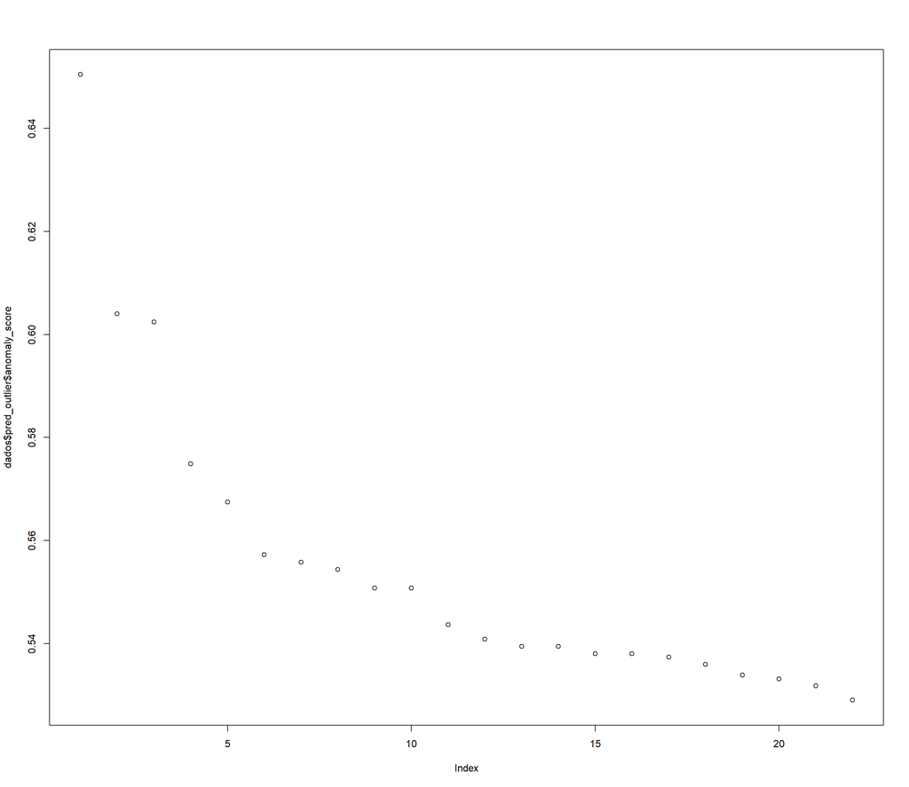

Vemos que a partir de um score de 0,56, a anomalia começa a ficar estável. Vamos considerar como outliers as empresas acima desse score, elas não serviriam para representar muito bem minha carteira em tese.

[interactive table not shown]

|  | Empresa | Máximo Draw Up | Máximo Drawdown | Observações no Máximo Draw Up | Observações no Máximo Drawdown | Número de Vezes Acima do Benchmark - IQT Ações Ativo | % de Vezes Abaixo do Benchmark - IQT Ações Ativo | Volatilidade | Alfa - IGP-M/IQT Ações Ativo | Beta - IGP-M/IQT Ações Ativo | Dividend Yield (Cotação Final) | Retorno do Maior Período de Ganhos | Retorno do Maior Período de Perdas |
| --- | --- | --- | --- | --- | --- | --- | --- | --- | --- | --- | --- | --- | --- |
| 1 | CVC BRASIL ON NM - CVCB3 | 0.2716879623 | -0.2774538387 | 4 | 45 | 44 | 0.5463917526 | 0.5619859878 | 0.551848299707717 | 1.56199100767336 | 0 | 0.1583564174 | -0.06265539533 |
| 2 | EZTEC ON NM - EZTC3 | 0.1046068583 | -0.3327940837 | 4 | 47 | 39 | 0.5979381443 | 0.4494072389 | -0.808052836078825 | 1.77178619491425 | 0.01372023081 | 0.1046068583 | -0.09647779479 |
| 3 | IRBBRASIL RE ON NM - IRBR3 | 0.178187404 | -0.2911084044 | 1 | 47 | 37 | 0.618556701 | 0.4810501849 | -0.804647890157671 | 1.13251067398492 | 0 | 0.02487562189 | -0.1015089163 |
| 4 | ITAUSA PN N1 - ITSA4 | 0.07796257796 | -0.2057698071 | 4 | 35 | 37 | 0.618556701 | 0.3019954046 | -0.346845272038773 | 0.912893581168364 | 0.008998696462 | 0.07796257796 | -0.08854125426 |
| 5 | JBS ON NM - JBSS3 | 0.1064680233 | -0.1375254325 | 6 | 16 | 62 | 0.3608247423 | 0.3013129128 | 0.522441771971138 | 0.545872378596208 | 0.03401404115 | 0.06120760959 | -0.02453740949 |
| 6 | LOCAMERICA ON NM - LCAM3 | 0.1141080549 | -0.271451876 | 5 | 47 | 43 | 0.5567010309 | 0.4150884659 | -0.159429418590127 | 1.78032954854496 | 0.007028721975 | 0.1141080549 | -0.04892296459 |
| 7 | MAGAZ LUIZA ON NM - MGLU3 | 0.08275520317 | -0.2915396341 | 1 | 62 | 39 | 0.5979381443 | 0.3877850568 | -0.841641303825101 | 1.12162864853546 | 0.001399131161 | 0.07931893688 | -0.1184387618 |
| 8 | MOVIDA ON NM - MOVI3 | 0.09481668774 | -0.270746407 | 4 | 34 | 42 | 0.5670103093 | 0.3932948177 | -0.333645714575354 | 1.4930548436637 | 0.008915199279 | 0.09481668774 | -0.1381548447 |
| 9 | OI ON N1 - OIBR3 | 0.1306818182 | -0.396 | 2 | 83 | 40 | 0.587628866 | 0.5595455785 | -0.805155066675356 | 1.42745975441439 | 0 | 0.09696969697 | -0.175 |
| 10 | PETROBRAS PN - PETR4 | 0.1375291375 | -0.3219794344 | 2 | 39 | 48 | 0.5051546392 | 0.559065504 | -0.0578622204312274 | 1.64519413701103 | 0.03028726577 | 0.09809456598 | -0.131557377 |

[output cut: 7 more lines]

Acima, vemos as empresas consideradas outliers e nosso novo dataset sem essas empresas.

# 3. Redução de dimensionalidade

O intuito é ver se cada atributo adiciona informação nova sobre as ações ou se são redundantes. Caso sejam, podemos resumir nosso dataset combinando alguns atributos em um número menor de dimensões.

Para isso, antes temos que colocar todos os atributos em uma mesma escala para que nenhum tenha a sua importância super dimensionada em relação aos demais simplesmente por estar em uma ordem de grandeza diferente.

```
##  Máximo Draw Up    Máximo Drawdown   Observações no Máximo Draw Up
##  Min.   :-1.3698   Min.   :-1.8875   Min.   :-1.42171
##  1st Qu.:-0.6579   1st Qu.:-0.4969   1st Qu.:-0.92846
##  Median :-0.1528   Median :-0.2295   Median : 0.05803
##  Mean   : 0.0000   Mean   : 0.0000   Mean   : 0.00000
##  3rd Qu.: 0.6096   3rd Qu.: 0.6941   3rd Qu.: 0.55127
##  Max.   : 2.5785   Max.   : 1.5534   Max.   : 2.03101
##  Observações no Máximo Drawdown
##  Min.   :-1.3962
##  1st Qu.:-1.0080
##  Median : 0.1011
##  Mean   : 0.0000
##  3rd Qu.: 0.4339
##  Max.   : 2.4303
##  Número de Vezes Acima do Benchmark - IQT Ações Ativo
##  Min.   :-1.1023
##  1st Qu.:-0.8307
##  Median :-0.2875
##  Mean   : 0.0000
##  3rd Qu.: 0.7987
##  Max.   : 2.2924
##  % de Vezes Abaixo do Benchmark - IQT Ações Ativo  Volatilidade
##  Min.   :-2.2924                                  Min.   :-1.5053
##  1st Qu.:-0.7987                                  1st Qu.:-0.7358
##  Median : 0.2875                                  Median :-0.1543
##  Mean   : 0.0000                                  Mean   : 0.0000
##  3rd Qu.: 0.8307                                  3rd Qu.: 0.6505
##  Max.   : 1.1023                                  Max.   : 1.5183
##  Alfa - IGP-M/IQT Ações Ativo Beta - IGP-M/IQT Ações Ativo
##  Min.   :-1.22018             Min.   :-1.99732
##  1st Qu.:-1.08152             1st Qu.:-0.65045
##  Median : 0.03366             Median :-0.05737
##  Mean   : 0.00000             Mean   : 0.00000
##  3rd Qu.: 0.80638             3rd Qu.: 0.86653
##  Max.   : 1.44656             Max.   : 1.33622
##  Dividend Yield (Cotação Final) Retorno do Maior Período de Ganhos
##  Min.   :-0.7701                Min.   :-1.5026
##  1st Qu.:-0.7701                1st Qu.:-0.8022
##  Median :-0.5462                Median :-0.1127
##  Mean   : 0.0000                Mean   : 0.0000
##  3rd Qu.: 0.2739                3rd Qu.: 1.0707
##  Max.   : 2.1184                Max.   : 1.7225
##  Retorno do Maior Período de Perdas
##  Min.   :-2.01795
##  1st Qu.:-0.64767
##  Median :-0.03304
##  Mean   : 0.00000
##  3rd Qu.: 0.77738
##  Max.   : 1.62723
```

```
##                                       Máximo Draw Up
##                                          -0.65790482
##                                      Máximo Drawdown
##                                          -1.04610767
##                        Observações no Máximo Draw Up
##                                           0.05802894
##                       Observações no Máximo Drawdown
##                                           0.43386827
## Número de Vezes Acima do Benchmark - IQT Ações Ativo
##                                          -0.83069848
##     % de Vezes Abaixo do Benchmark - IQT Ações Ativo
##                                           0.83069848
##                                         Volatilidade
##                                           0.31127226
##                         Alfa - IGP-M/IQT Ações Ativo
##                                          -1.08652431
##                         Beta - IGP-M/IQT Ações Ativo
##                                           1.31783877
##                       Dividend Yield (Cotação Final)
##                                           0.27393370
##                   Retorno do Maior Período de Ganhos
##                                           0.03451039
##                   Retorno do Maior Período de Perdas
##                                          -0.11563304
```

Acima, vemos como ficaram as estatísticas dos dados após colocarmos os nossos dados em uma mesma escala centrada em zero. Também vemos o exemplo da EZTEC3, uma ação que tem, por exemplo, um beta acima da média e um alfa abaixo da média das ações da minha carteira.

Agora, vamos olhar as correlações para ver se temos atributos muito correlacionados ou não (espera-se que sim pois são métricas da mesma natureza, que usam o preço da ação como base). Caso não tenhamos, uma redução de dimensionalidade não seria necessária em princípio.

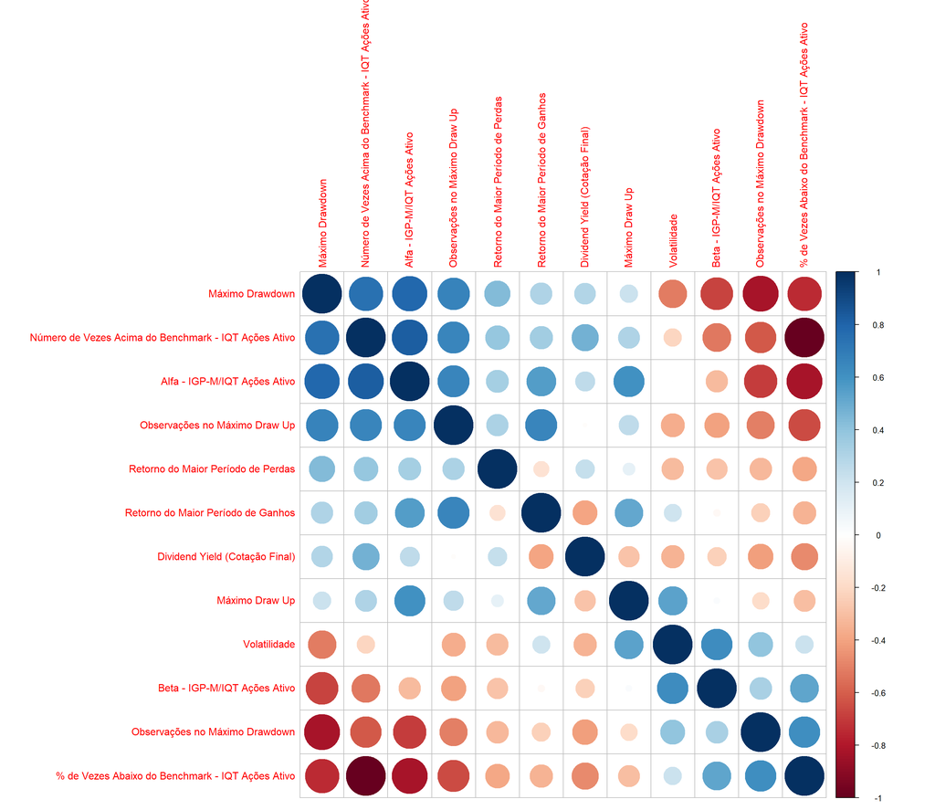

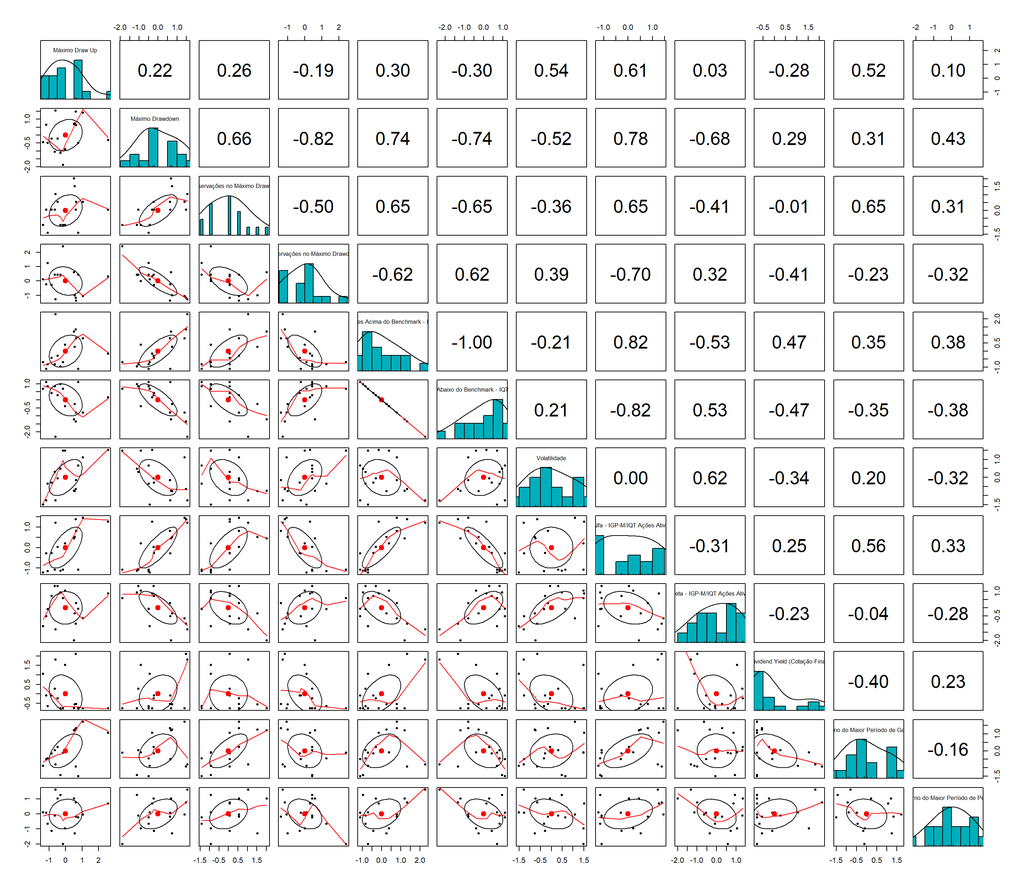

Parece que temos atributos bastante correlacionados (uma análise mais formal, estatisticamente falando, faria testes de significância de correlação), provavelmente conseguiremos resumir este dataset em uma combinação com menos dimensões. Vamos utilizar a técnica PCA para resumir nossos atributos:

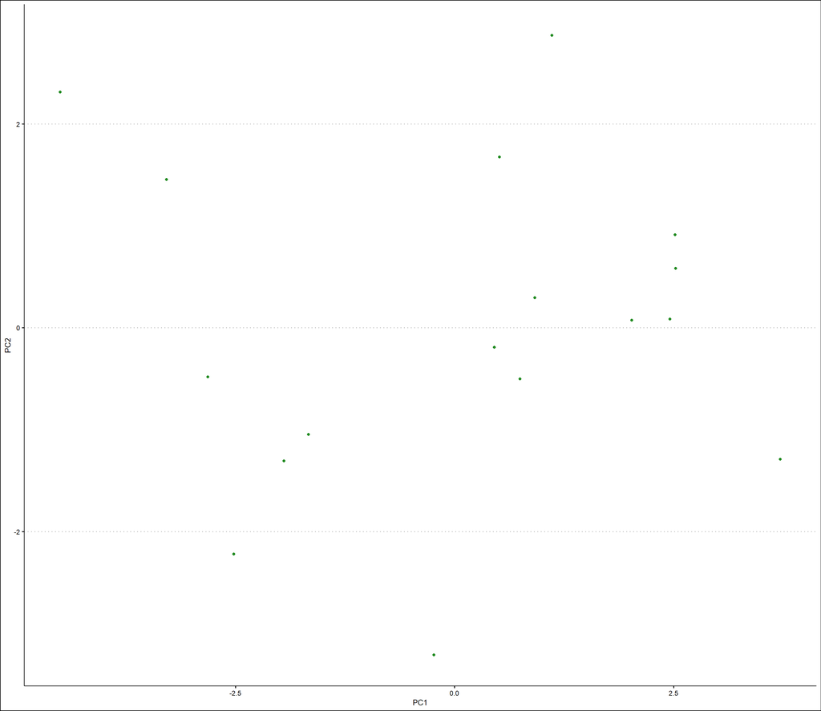

Acima, vemos as dimensões de maior importância para nossa análise.

Abaixo, vemos os pesos de cada atributo original em cada PC (principal component). Para a PC1, por exemplo, os coeficientes maiores são os do atributo “Máximo Draw Down” e do “% de Vezes Abaixo do Benchmark - IQT Ações Ativo”, em módulo. Isso significa que as empresas que possuem esses coeficientes maiores terão maior peso no PC1. Essa importância vai mudando dependendo do PC que estejamos olhando, como podemos ver observado as demais colunas.

```
##                                                             PC1         PC2
## Máximo.Draw.Up                                       -0.1391066 -0.49555278
## Máximo.Drawdown                                      -0.3847993  0.07802095
## Observações.no.Máximo.Draw.Up                        -0.3250287 -0.12921413
## Observações.no.Máximo.Drawdown                        0.3287747 -0.06706631
## Número.de.Vezes.Acima.do.Benchmark...IQT.Ações.Ativo -0.3834033 -0.01539802
## X..de.Vezes.Abaixo.do.Benchmark...IQT.Ações.Ativo     0.3834033  0.01539802
## Volatilidade                                          0.1636971 -0.47531398
## Alfa...IGP.M.IQT.Ações.Ativo                         -0.3690092 -0.22314229
## Beta...IGP.M.IQT.Ações.Ativo                          0.2575526 -0.24379095
## Dividend.Yield..Cotação.Final.                       -0.1593403  0.37858736
## Retorno.do.Maior.Período.de.Ganhos                   -0.1757049 -0.46734803
## Retorno.do.Maior.Período.de.Perdas                   -0.1982089  0.17256691
##                                                              PC3           PC4
## Máximo.Draw.Up                                       -0.20410444  2.886511e-01
## Máximo.Drawdown                                       0.12904550  3.505017e-02
## Observações.no.Máximo.Draw.Up                         0.37401184  1.043858e-02
## Observações.no.Máximo.Drawdown                        0.09030122  1.317460e-01
## Número.de.Vezes.Acima.do.Benchmark...IQT.Ações.Ativo -0.18705280 -1.280101e-01
## X..de.Vezes.Abaixo.do.Benchmark...IQT.Ações.Ativo     0.18705280  1.280101e-01
## Volatilidade                                         -0.42438806  2.181633e-05
## Alfa...IGP.M.IQT.Ações.Ativo                         -0.18438029 -2.260432e-02
## Beta...IGP.M.IQT.Ações.Ativo                         -0.31624748 -6.525332e-02
## Dividend.Yield..Cotação.Final.                       -0.51937376 -3.244648e-01
## Retorno.do.Maior.Período.de.Ganhos                    0.34205492 -2.213114e-01
## Retorno.do.Maior.Período.de.Perdas                   -0.15102159  8.403498e-01
##                                                               PC5         PC6
## Máximo.Draw.Up                                       -0.131935682 -0.38464579
## Máximo.Drawdown                                       0.138087964 -0.34026437
## Observações.no.Máximo.Draw.Up                         0.110671566  0.45606578
## Observações.no.Máximo.Drawdown                       -0.607778193  0.35445937
## Número.de.Vezes.Acima.do.Benchmark...IQT.Ações.Ativo -0.276033402  0.22448954
## X..de.Vezes.Abaixo.do.Benchmark...IQT.Ações.Ativo     0.276033402 -0.22448954
## Volatilidade                                         -0.157602354  0.00455885
## Alfa...IGP.M.IQT.Ações.Ativo                          0.088890463 -0.08399635
## Beta...IGP.M.IQT.Ações.Ativo                          0.611779030  0.39263351
## Dividend.Yield..Cotação.Final.                        0.004017697  0.13236109
## Retorno.do.Maior.Período.de.Ganhos                    0.085246897  0.20286535
## Retorno.do.Maior.Período.de.Perdas                    0.123274132  0.28623099
##                                                              PC7         PC8
```

[output cut: 23 more lines]

```
## Retorno.do.Maior.Período.de.Ganhos                   -0.39544105  0.11564719
## Retorno.do.Maior.Período.de.Perdas                   -0.17986095 -0.04034496
##                                                              PC11          PC12
## Máximo.Draw.Up                                        0.217511561  2.615692e-10
## Máximo.Drawdown                                       0.621977844  1.031085e-09
## Observações.no.Máximo.Draw.Up                        -0.037600984 -9.036913e-11
## Observações.no.Máximo.Drawdown                        0.207598452  2.575217e-10
## Número.de.Vezes.Acima.do.Benchmark...IQT.Ações.Ativo  0.070060482  7.071068e-01
## X..de.Vezes.Abaixo.do.Benchmark...IQT.Ações.Ativo    -0.070060484  7.071068e-01
## Volatilidade                                          0.012971204 -7.303830e-12
## Alfa...IGP.M.IQT.Ações.Ativo                         -0.625227257 -7.747217e-10
## Beta...IGP.M.IQT.Ações.Ativo                          0.254650577  4.113312e-10
## Dividend.Yield..Cotação.Final.                        0.182124236  1.920628e-10
## Retorno.do.Maior.Período.de.Ganhos                    0.149696847  1.992337e-10
## Retorno.do.Maior.Período.de.Perdas                    0.001308942 -3.857748e-11
```

Ainda, abaixo vemos que com 3 dimensões alcançamos 80% da variância dos nossos dados. Entende-se então que 3 dimensões resumem bem os nossos dados (regra de ouro), os outros 20% podem ser considerados como ruído.

```
## Importance of components:
##                           PC1    PC2    PC3     PC4     PC5     PC6     PC7
## Standard deviation     2.3929 1.5811 1.1102 0.92513 0.80757 0.74108 0.41644
## Proportion of Variance 0.4772 0.2083 0.1027 0.07132 0.05435 0.04577 0.01445
## Cumulative Proportion  0.4772 0.6855 0.7882 0.85953 0.91388 0.95964 0.97410
##                            PC8     PC9    PC10   PC11      PC12
## Standard deviation     0.37115 0.31152 0.24823 0.1202 7.461e-11
## Proportion of Variance 0.01148 0.00809 0.00513 0.0012 0.000e+00
## Cumulative Proportion  0.98557 0.99366 0.99880 1.0000 1.000e+00
```

A partir de agora, vamos trabalhar com o nosso dataset resumido (3 dimensões). Vejamos o quanto cada dimensão explica da variância dos nossos dados.

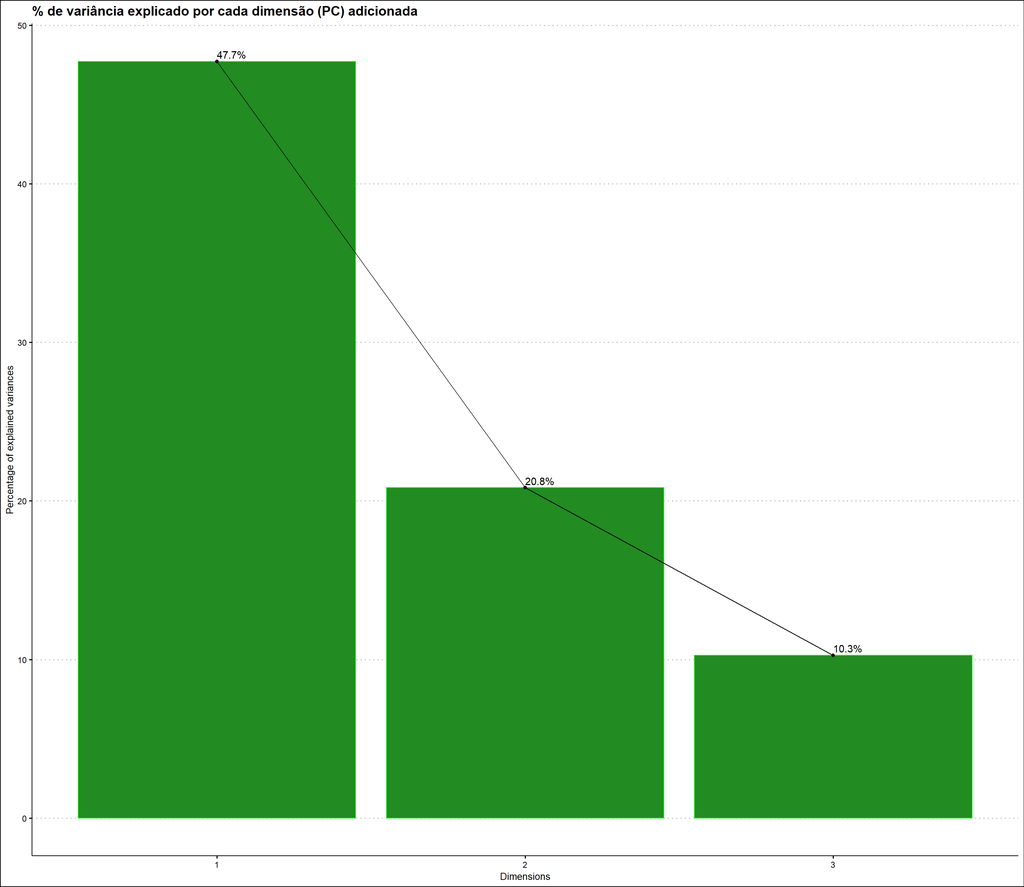

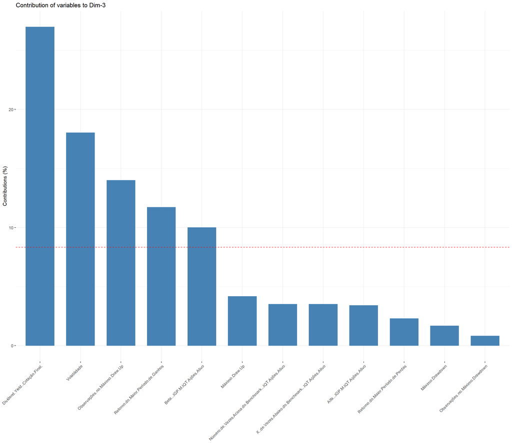

Com o nosso dataset reduzido, vejamos como ficaram as correlações entre os atributos resumidos. Espera-se que seja zero, pois a técnica do PCA só deixa a informação nova adicionada pelas variáveis (uma correlação alta entre os atributos não significa uma relação causal entre eles mas sim que a informação trazida por eles é redundante).

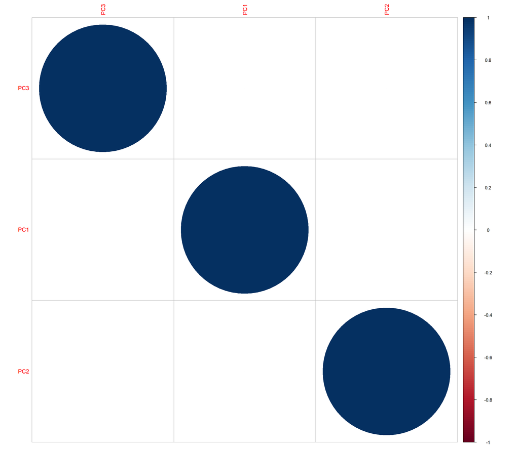

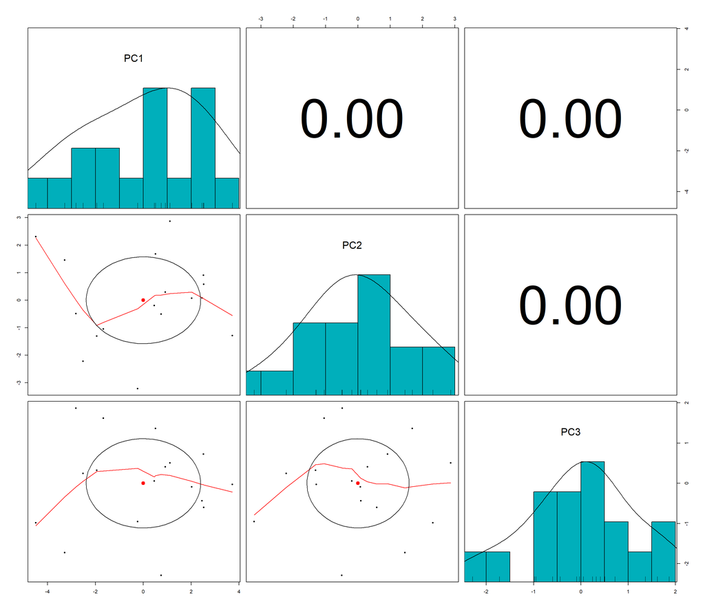

Perfeito, agora não temos redundância nos dados. Além disso, com esta técnica, estou retirando do meu dado qualquer ruído de medição, ou seja, se há alguma especificidade na minha amostra, eu retiro e fico apenas com as características gerais dos meus dados.

# 4. Clusterização

Testei 2 métodos para a escolha do número de clusters ótimo: soma dos quadrados dos erros intra clusters (wss), silhueta média (calcula a distância de cada ponto ao centroide do seu cluster e a distância de cada ponto a outro cluster mais próximo e divide a diferença dessas distâncias pela maior delas); e 2 métodos para a clusterização: hierárquica e kmeans (diferente do kmeans, o método hierárquico não assume que os dados são bem representados pelos centroides/média).

Aqui, apresentaremos apenas os melhores obtidos e, depois, interpretaremos qual deles faz mais sentido.

# 4.1. Escolhendo o número de grupos (k) para usar com o kmeans

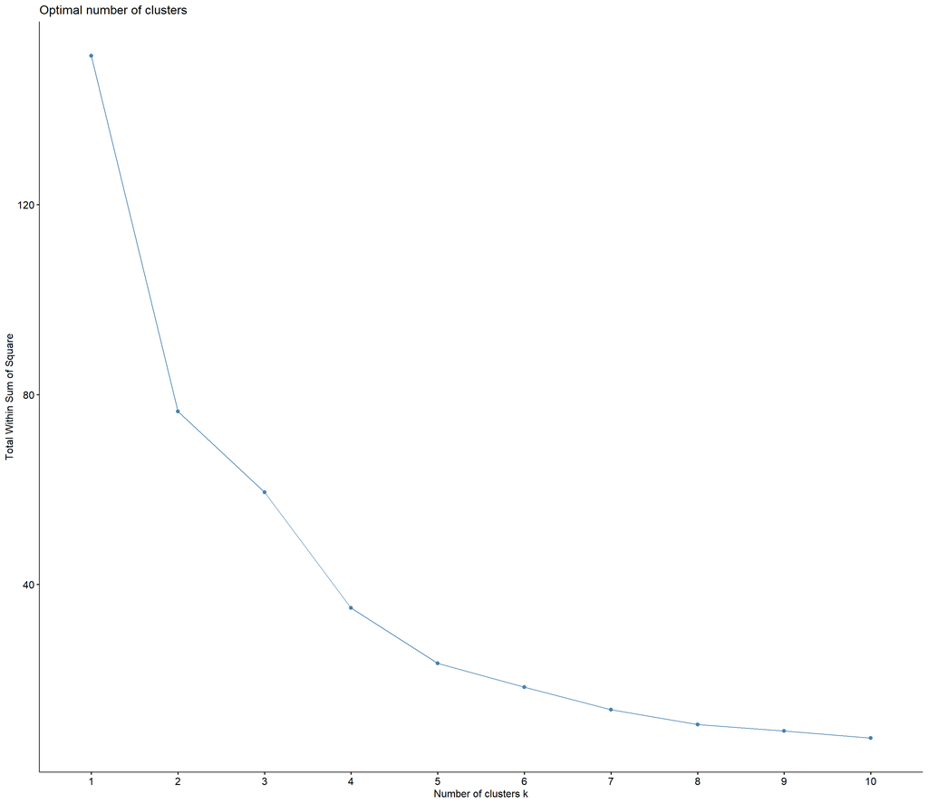

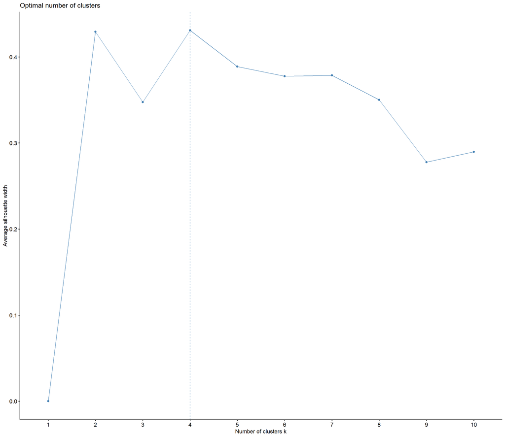

```
##   cluster size ave.sil.width
## 1       1    2          0.65
## 2       2    2          0.49
## 3       3    5          0.43
## 4       4    8          0.32
```

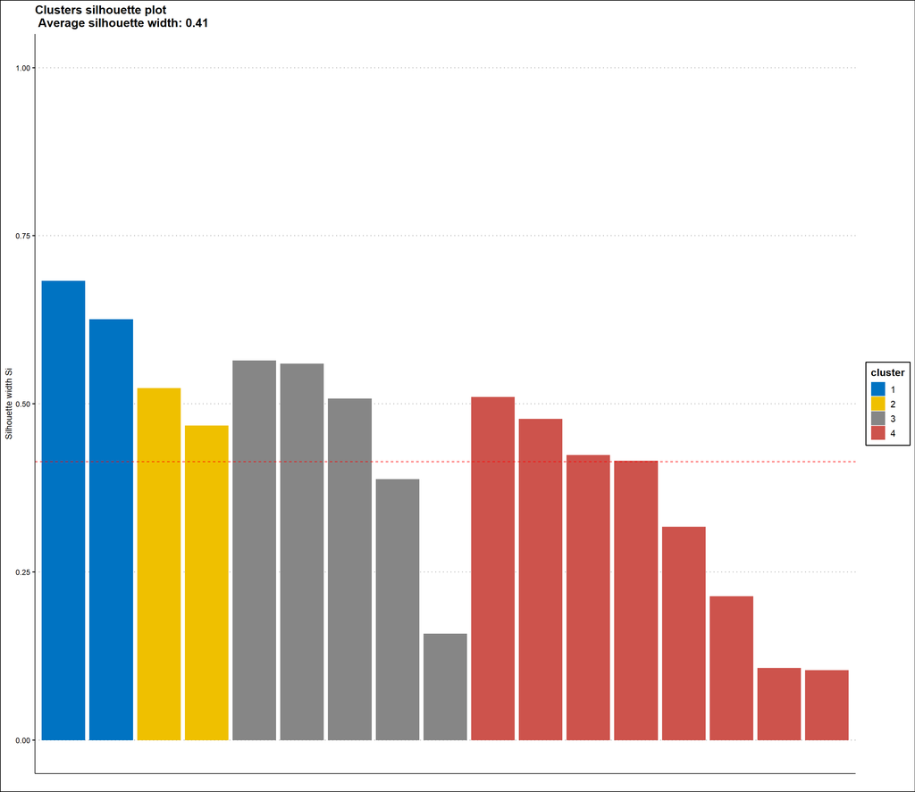

Vemos que, para o kmeans, um k ideal seria 4 ou 5 (5 seria um o número ideal pelo método WSS e, pelo método da silhueta, este número seria de 4).

## 4.2. Escolhendo o número de grupos (k) para usar com a clusterização hierárquica

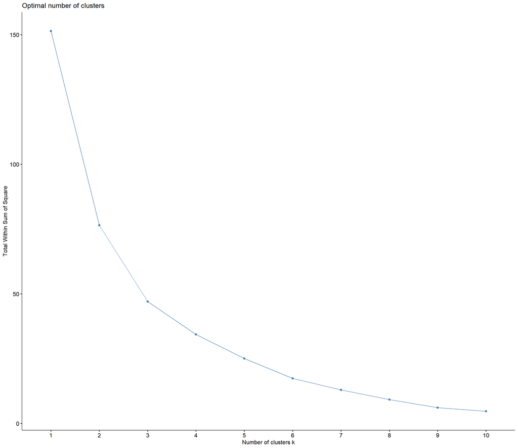

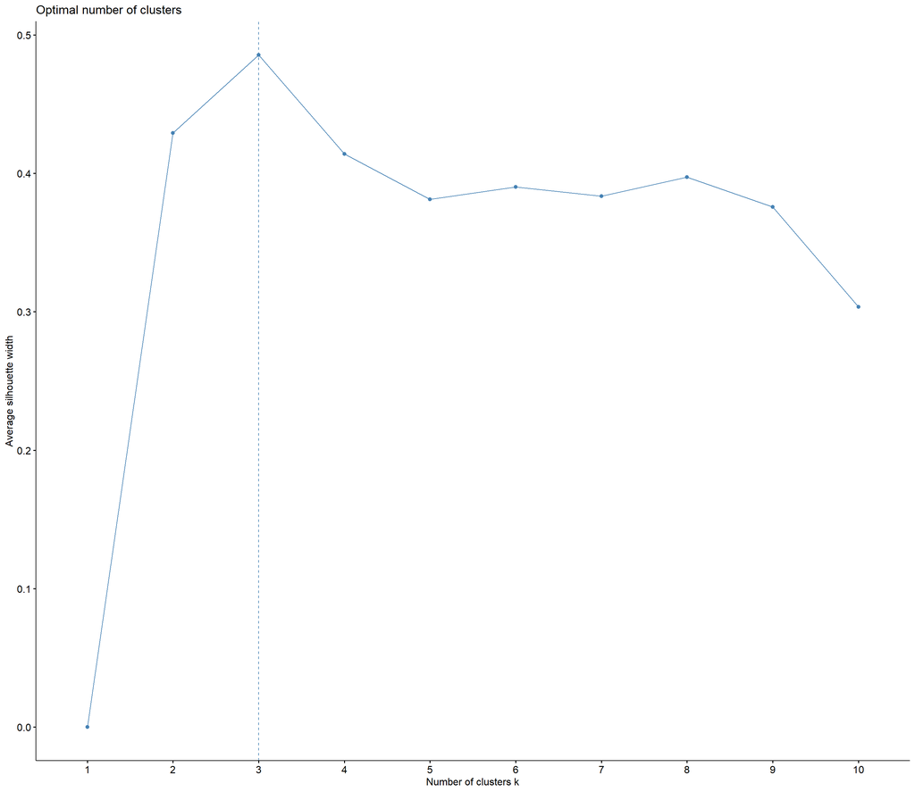

```
##   cluster size ave.sil.width
## 1       1    5          0.45
## 2       2   10          0.47
## 3       3    2          0.65
```

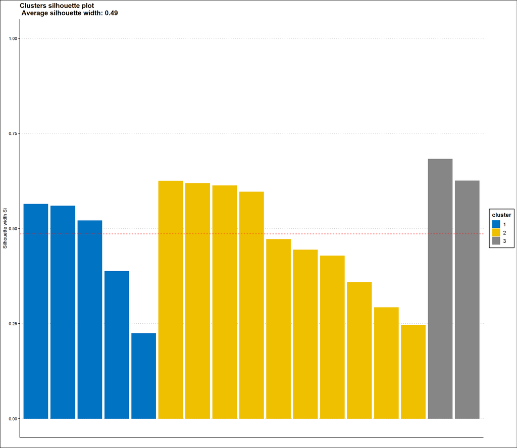

Testei os resultados para 3, 4, 5 e 6 grupos. Com 4 e 6 grupos, a separação não estava boa, quando visualizei os clusters havia sobreposição entre dois dos grupos formados, com o menor deles estando totalmente dentro do maior. Logo, um agrupamento com 4 e 6 grupos foi descartado.

Os resultados para 3 grupos foram os melhores, com grupos bem separados e com a melhor silhueta média obtida (melhor equilíbrio entre coesão no grupo e separação com relação entre os demais). Com 5 grupos, os resultados ficaram bons visualmente também, mas a silhueta não foi tão boa. Assim, escolhi o resultado com 3 grupos (o resultado com 3 grupos obtido por meio do kmeans e com o método hierárquico foram semelhantes), vamos interpretá-lo e ver que informação podemos extrair.

## 4.3. Interpretação dos resultados

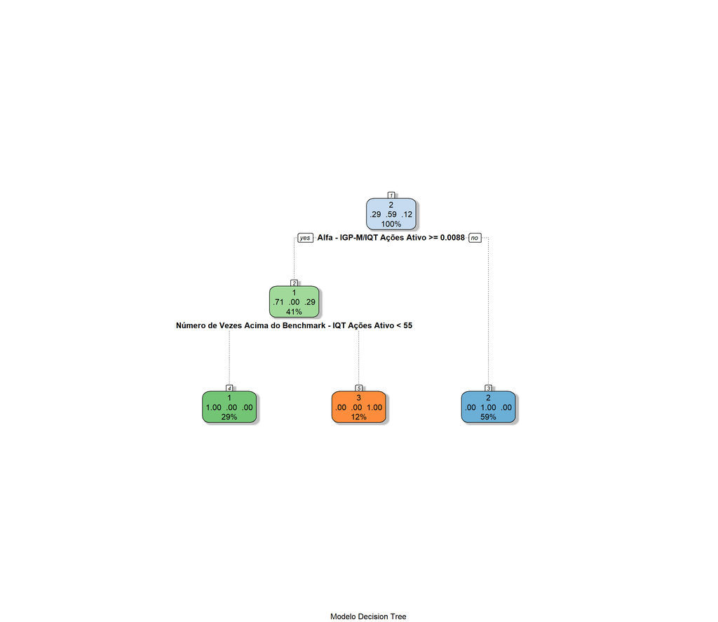

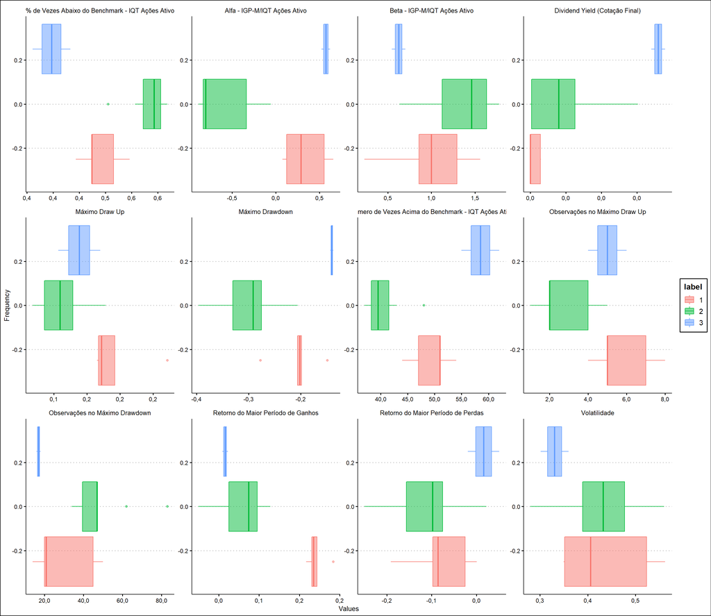

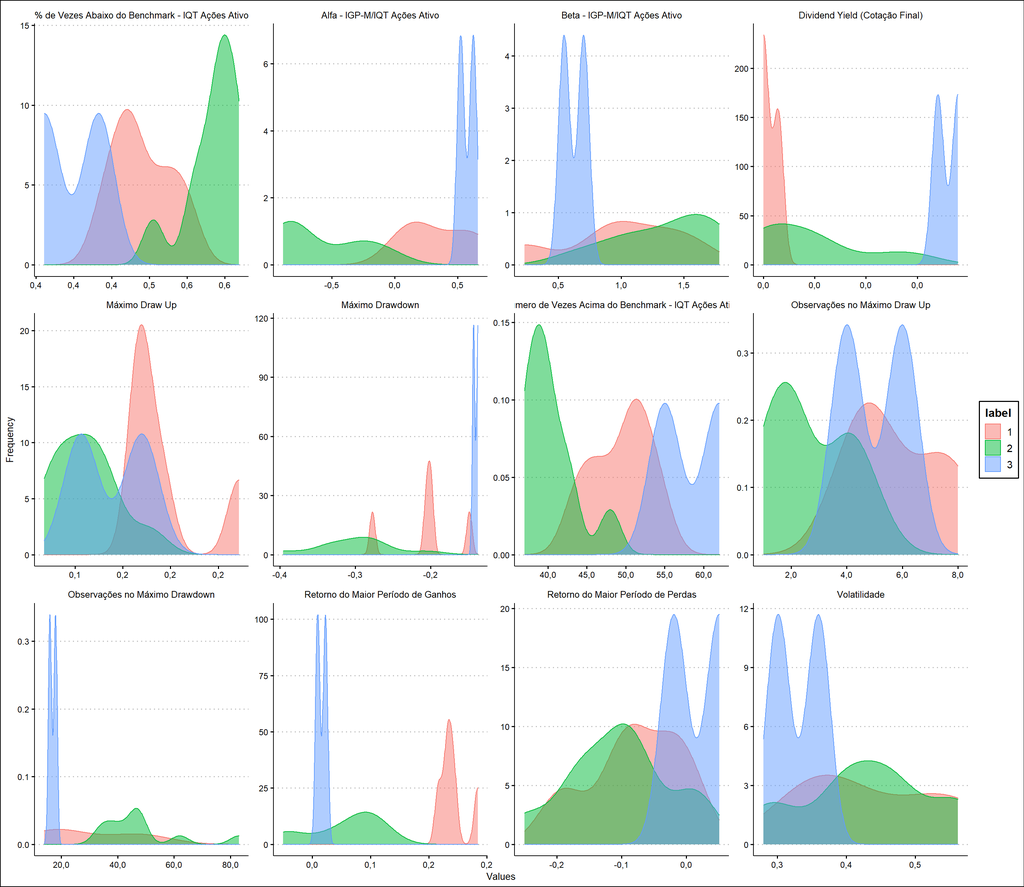

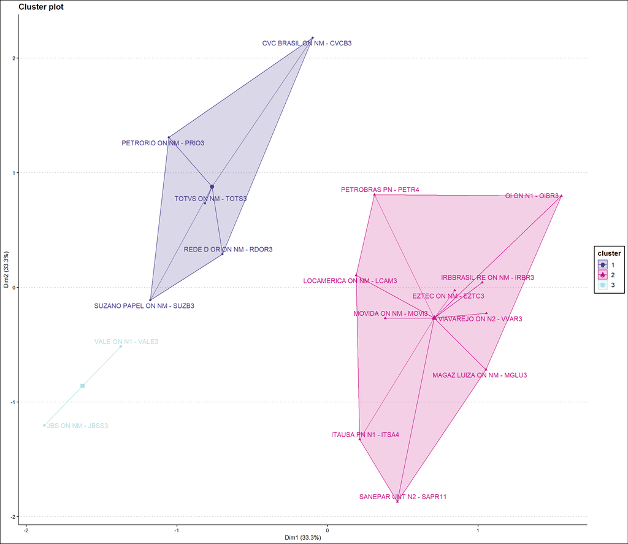

Com base no resultado da clusterização, podemos dividir claramente a minha carteira em 2 grupos com base no excesso de retorno em relação ao restante do mercado (alfa): as ações com Alfa maior que 0,88% no período (grupos 1 e 3) e as com alfa menor que este valor (grupo 2).

Ações do grupo 1: Petro Rio (PRIO3), Totvs (TOTS3), Rede D’Or (RDOR3), CVC Brasil (CVCB3) e Suzano (SUZB3).

Ações do grupo 3: Vale (VALE3) e JBS (JBSS3).

Ações do grupo 2: Petrobras (PETR4), Oi (OIBR3), IRB Brasil (IRBR3), EZTEC (EZTC3), Movida (MOVI3), Via Varejo (VVAR3), Magazine Luiza (MGLU3), Sanepar (SAPR11), Itau S.A. (ITSA4) e Locamerica (LCAM3).

O curioso é que, olhando o boxplot do Beta e comparando os boxplots dos grupos 1 e 3 com o do grupo 2, vemos que as ações do grupo 3 apresentam um risco de mercado menor que as ações do grupo 2, ou seja, apresentaram um retorno maior e pouco correlacionado com o mercado no período.

Isso significa que se uma crise atingisse o mercado brasileiro no período analisado, a performance dessas ações não seria antigida ou seria pouco atingida em comparação com as ações do grupo 2.

E é curioso porque normalmente as ações com maior potencial de ganho são as que possuem o Beta elevado. Poderíamos dizer as ações dos grupos 1 e 3 , no período selecionado, em comparação com as ações do grupo 2, representaram o *oceano azul* dos investimentos: ações com maior retorno e menor risco.

Indo mais afundo no nosso oceano azul, olhando o boxplot do Dividend Yield, as ações do grupo 3 seriam ainda melhores que as do grupo 1 no período analisado, pois apresentam alto retorno, baixo risco de mercado e bons dividendos em comparação aos seus preços…O que é ainda mais curioso se pensarmos em termos das estratégias tradicionais de investimento em ações, que apresentam a dicotomia investimento em crescimento (o investidor ganharia dinheiro via ganhos de capital) x investimento em valor (o investidor ganharia dinheiro não com o aumento do preço das ações, mas sim com a renda dos dividendos pagos a ele pela empresa periodicamente), como já citado anteriormente.

Falando em Dividend Yield, vimos por meio da árvore, que, neste estudo, esse indicador tão tradicional na análise fundamentalista para classificar ações, não foi determinante para a formação dos grupos.

Portanto, talvez eu devesse aumentar o investimento nessas ações dos grupos 1 e 3…Mas, para isso, precisaríamos fazer a análise para um período maior a fim de confirmar essa tese.

¹ Fonte: [Quantum Finance](https://quantumfinance.com.br/)

² A análise de um período maior, bem como generalizada a todas as empresas negociadas na Bolsa brasileira seria o ideal, no entanto pela falta de tempo e recursos computacionais, a proposta aqui é uma análise menos extensa.

³ Autoria: [Quantum Finance](https://quantumfinance.com.br/). Definição: índice Quantum Ibovespa Ativo é a média ponderada pelo volume de todos os fundos de ações ativos Ibovespa, já líquido de todos os custos.

<sup>4</sup> Quando o investidor adquire as ações após a Data-Com ele perde o direito de ganhar os proventos no dia do pagamento. Essa data é chamada de Data-Ex.

Exemplo: No dia 01/11/2020 a Petrobras anunciou que vai pagar dividendos no montante de R$0,20 por ação aos seus acionistas que detivessem as ações até dia 25/11/2020. Essa data 25/11/2020 é a Data-Com, porque os acionistas que compraram as ações da empresa até dia 25 vão receber os dividendos na data combinada, no caso dia 02/12/2020.

A Data-Ex é dia 26/11/2020, pois os acionistas que compraram as ações após o dia 25 (Data-Com) não ganham mais o direito de receber os dividendos no dia 02/12/2020. Fonte: [Vitreo](https://atendimento.vitreo.com.br/hc/pt-br/articles/360052857931-O-que-%C3%A9-Data-Com-e-Data-Ex-)

<sup>5</sup> Escolhi este índice “como ativo sem risco” por ser um índice de inflação. Se você investir em um ativo cujo retorno esteja indexado ao IGP-M, você está praticamente livre de perdas (seu dinheiro sempre renderá no mínimo o mesmo que o IGP-M).

E por que não escolher o IPCA, que é o índice oficial de inflação no Brasil? Os dois índices fazem fotografias da economia com ângulos também diferentes. [No IPCA, o enquadramento é bem mais fechado. Já o IGP-M, registra um ambiente muito maior da economia.](https://g1.globo.com/jornal-nacional/noticia/2021/01/05/entenda-a-diferenca-entre-o-igp-m-e-o-ipca-e-como-eles-sao-calculados.ghtml)

<sup>6</sup> Em razão da existência de, por exemplo, assimetria de informações, pode ser que o mercado não reflita todos os riscos no momento do investimento.

**Disclaimer: este estudo não representa uma recomendação de compra ou venda de ações.**